# Notebook

### Web Information Retrieval and Data Mining - Assignment 3

```
Student: Niels, Uphoff (0864198)
```

#### Answer 1.1, Baseline (4p)

- Dense network, at least 3 layers, shaped like a pyramid
  - Last layer: 10 nodes, sigmoid.
  - Loss: categorical cross-entropy. Metric: accuracy
- No preprocessing, regularization. Get at least 70% accuracy.
- Explain design decisions. Discuss performance.
  - Does it overfit (large/growing gap between loss and val_loss)?

[output not shown]

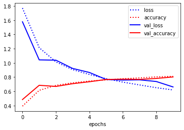

```
Model: "model_1_1"
_________________________________________________________________
Layer (type)                 Output Shape              Param #
=================================================================
reshape (Reshape)            (None, 3072)              0
_________________________________________________________________
dense (Dense)                (None, 1536)              4720128
_________________________________________________________________
dense_1 (Dense)              (None, 768)               1180416
_________________________________________________________________
dense_2 (Dense)              (None, 384)               295296
_________________________________________________________________
dense_3 (Dense)              (None, 10)                3850
=================================================================
Total params: 6,199,690
Trainable params: 6,199,690
Non-trainable params: 0
_________________________________________________________________
None
def build_model_1_1(numhiddenlayers=3):
    model = models.Sequential(name='model_1_1')
    #input layer
    model.add(layers.Reshape((3072,), input_shape=(32,32,3)))

    number_of_nodes = 3072
    #add hidden layers (half as many nodes) with rectified linear units
    for i in range(numhiddenlayers):
      number_of_nodes /= 2
      model.add(layers.Dense(number_of_nodes, activation='relu'))

    #output layer should output the predicted label by percentage
    model.add(layers.Dense(10, activation='softmax'))

    #opt = optimizers.SGD(learning_rate=0.01, momentum=0.5, nesterov=True)
    opt = optimizers.Adagrad(learning_rate=0.01)
    model.compile(optimizer=opt,
                  loss='categorical_crossentropy',
                  metrics=['accuracy'])
    return model
```

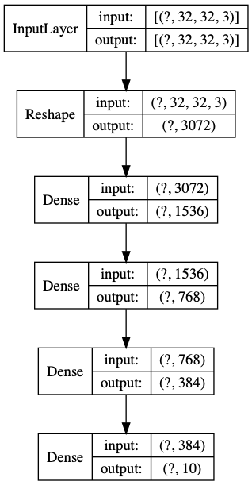

#### Answer 1.2, Preprocess (2p)

- Convert images to greyscale, other preprocessing optional.
  - Input shape should be (32,32,1)
- Explain design decisions. Is it better? Why (not)?
  - Color information is likely not so useful for classification. Greyscale makes the network smaller, less parameters to learn, less likely to overfit.

[output not shown]

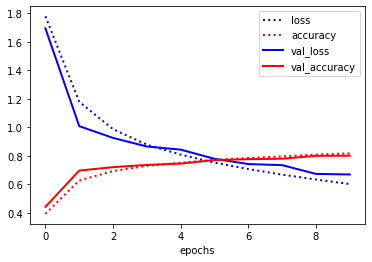

```
Model: "model_1_2"
_________________________________________________________________
Layer (type)                 Output Shape              Param #
=================================================================
reshape_1 (Reshape)          (None, 1024)              0
_________________________________________________________________
dense_4 (Dense)              (None, 1536)              1574400
_________________________________________________________________
dense_5 (Dense)              (None, 768)               1180416
_________________________________________________________________
dense_6 (Dense)              (None, 384)               295296
_________________________________________________________________
dense_7 (Dense)              (None, 10)                3850
=================================================================
Total params: 3,053,962
Trainable params: 3,053,962
Non-trainable params: 0
_________________________________________________________________
None
def build_model_1_2(numhiddenlayers=3):
    model = models.Sequential(name='model_1_2')
    #input layer
    model.add(layers.Reshape((1024,), input_shape=(32,32,1)))

    number_of_nodes = 3072
    #add hidden layers (half as many nodes) with rectified linear units
    for i in range(numhiddenlayers):
      number_of_nodes /= 2
      model.add(layers.Dense(number_of_nodes, activation='relu'))

    #output layer should output the predicted label by percentage
    model.add(layers.Dense(10, activation='softmax'))

    #opt = optimizers.SGD(learning_rate=0.01, momentum=0.5, nesterov=True)
    opt = optimizers.Adagrad(learning_rate=0.01)
    model.compile(optimizer=opt,
                  loss='categorical_crossentropy',
                  metrics=['accuracy'])
    return model
```

#### Answer 1.3, Tune (4p)

- Regularize the model. What works best?
  - Should consider batch normalization, dropout, l1/l2 regularization (or Nesterov)
- Tune other hyperparameters (e.g. learning rate, batch size,...) as you see fit.
  - At least consider tuning learning rate, ideally also momentum, decay, other optimizers
- Explain your findings and final design decisions. Discuss the results.
  - Should be better, at least it shouldn't overfit

[output not shown]

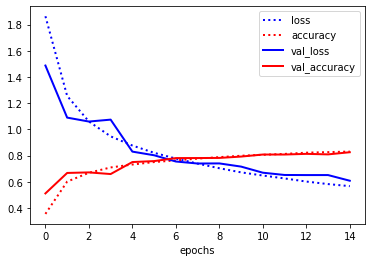

```
def build_model_1_3(numhiddenlayers=3):
    model = models.Sequential(name='model_1_3')
    #input layer
    model.add(layers.Reshape((1024,), input_shape=(32,32,1)))

    dropout_rate = 0.1
    number_of_nodes = 3072
    #add hidden layers (half as many nodes) with rectified linear units
    for i in range(numhiddenlayers):
      number_of_nodes /= 2
      layer_dropout = dropout_rate / (i+1)
      #because we use dropout we need more nodes in each layer
      nodes = number_of_nodes * (1 + layer_dropout)
      model.add(layers.Dense(nodes, activation='relu', bias_regularizer=tf.keras.regularizers.l2(l=0.01)))
      model.add(layers.Dropout(rate=layer_dropout))

    #output layer should output the predicted label by percentage
    model.add(layers.Dense(10, activation='softmax'))

    opt = optimizers.Adagrad(learning_rate=0.01)
    model.compile(optimizer=opt,
                  loss='categorical_crossentropy',
                  metrics=['accuracy'])
    return model
```

#### Answer 2.1, ConvNet (7p)

- Build a sequential ConvNet, get at least 90% accuracy.
  - Conv2D layers, input shape (32,32,1)
  - Consider using blocks of Conv2D layers with maxpooling in between
  - Use zero-padding in Conv2D layers because the images are small
  - At least one dense hidden layer and dense output layer (sigmoid)
  - Consider adding batch normalization, dropout
  - Consider small dropout rates in beginning, larger dropout rates later in network
  - Consider other optimizers and tuning learning rate, momentum,...
- Explain what you did and why (800 chars). Is it working well?
  - Should be quite elaborate and sensible

[output not shown]

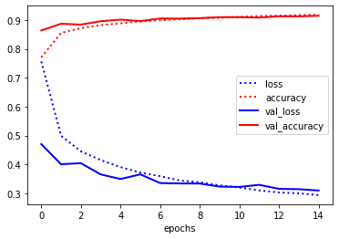

```
Model: "model_2_1"
_________________________________________________________________
Layer (type)                 Output Shape              Param #
=================================================================
conv2d (Conv2D)              (None, 28, 28, 32)        832
_________________________________________________________________
max_pooling2d (MaxPooling2D) (None, 14, 14, 32)        0
_________________________________________________________________
batch_normalization (BatchNo (None, 14, 14, 32)        128
_________________________________________________________________
dropout_3 (Dropout)          (None, 14, 14, 32)        0
_________________________________________________________________
conv2d_1 (Conv2D)            (None, 11, 11, 64)        32832
_________________________________________________________________
max_pooling2d_1 (MaxPooling2 (None, 5, 5, 64)          0
_________________________________________________________________
batch_normalization_1 (Batch (None, 5, 5, 64)          256
_________________________________________________________________
dropout_4 (Dropout)          (None, 5, 5, 64)          0
_________________________________________________________________
conv2d_2 (Conv2D)            (None, 3, 3, 128)         73856
_________________________________________________________________
max_pooling2d_2 (MaxPooling2 (None, 1, 1, 128)         0
_________________________________________________________________
batch_normalization_2 (Batch (None, 1, 1, 128)         512
_________________________________________________________________
dropout_5 (Dropout)          (None, 1, 1, 128)         0
_________________________________________________________________
flatten (Flatten)            (None, 128)               0
_________________________________________________________________
dense_12 (Dense)             (None, 64)                8256
_________________________________________________________________
dense_13 (Dense)             (None, 10)                650
=================================================================
Total params: 117,322
Trainable params: 116,874
Non-trainable params: 448
_________________________________________________________________
None
def build_model_2_1(numhiddenlayers=3, modelname='model_2_1'):
```

[output cut: 14 more lines]

```
    model.add(layers.BatchNormalization())
    model.add(layers.Dropout(rate=0.1))

    #convert back to single dimension
    model.add(layers.Flatten())
    #dense layer with a dropout
    model.add(layers.Dense(64, activation='relu', kernel_regularizer=tf.keras.regularizers.l2(l=1e-4)))
    #output layer should output the predicted label by percentage
    model.add(layers.Dense(10, activation='softmax'))

    opt = optimizers.Adagrad(learning_rate=0.02)
    model.compile(optimizer=opt,
                  loss='categorical_crossentropy',
                  metrics=['accuracy'])
    return model
```

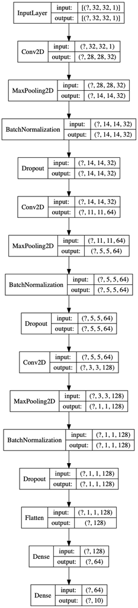

#### Answer 2.2, Data Augmentation (3p)

- Augment the preprocessed training data.
  - Use small variations (small shifts up-down, left-right) of flips becasue the images are small
  - Large shifts and rotations distort the image too much
- Explain what you did and why. Discuss the performance of the model.

[output not shown]

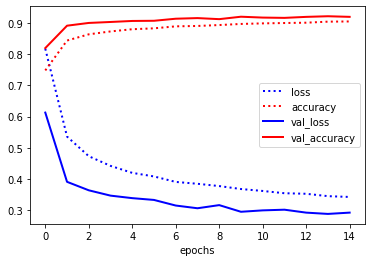

```
train_datagen = ImageDataGenerator(
    rotation_range=0.4,
    width_shift_range=0.05,
    height_shift_range=0.05,
    shear_range=0.0,
    zoom_range=0.0,
    zca_whitening=False,
    horizontal_flip=False,
    fill_mode='nearest')
```

#### Answer 3.1, Misclassifications (2p)

[output not shown]

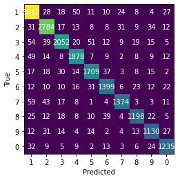

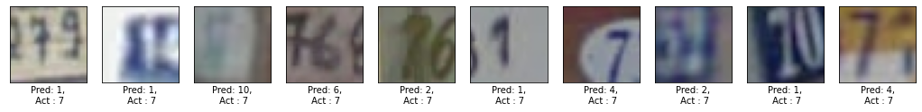

#### Answer 3.2, Activations (4p)

- Retrieve and visualize the activations for one example
- For every filter for different convolutional layers (at different depths in the network).
- Give an explanation. Is your model indeed learning something useful?
  - Should detect edges etc in first layers, higher-order object (e.g. interesting regions) in deeper layers.

[output not shown]

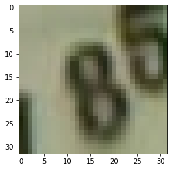

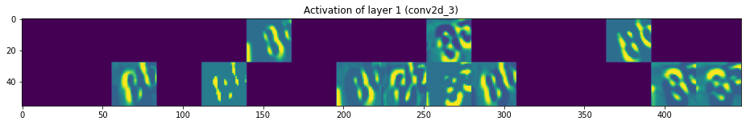

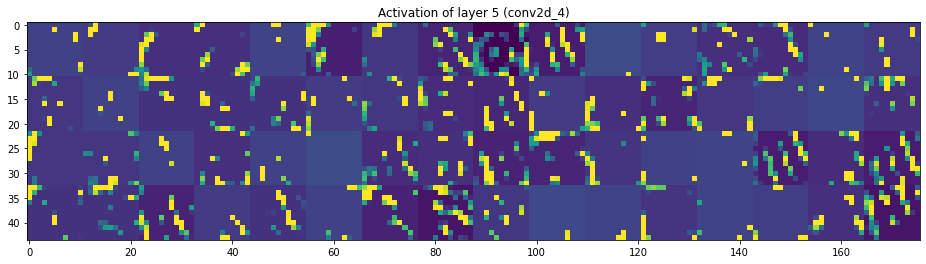

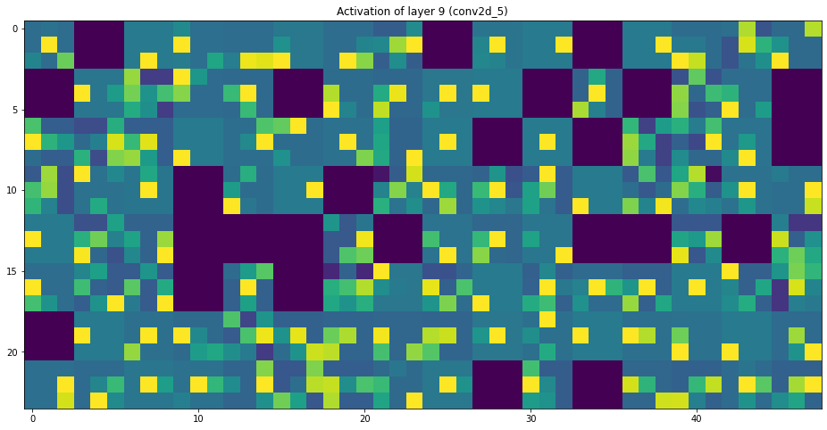

#### Answer 3.3, Class activation map (4p)

- Show a class activation map for your last convolutional layer
- Superimpose the activation map over the image, or plot side by side
  - Should make sense, detect interesting regions to classify the number

[output not shown]

#### Answer 4.1, Fast feature extraction (5p)

[output not shown]

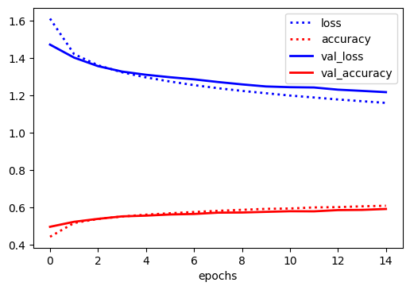

```
Model: "model_4_1"
_________________________________________________________________
Layer (type)                 Output Shape              Param #
=================================================================
vgg16 (Model)                (None, 1, 1, 512)         14714688
_________________________________________________________________
flatten_7 (Flatten)          (None, 512)               0
_________________________________________________________________
dense_26 (Dense)             (None, 256)               131328
_________________________________________________________________
dense_27 (Dense)             (None, 10)                2570
=================================================================
Total params: 14,848,586
Trainable params: 133,898
Non-trainable params: 14,714,688
_________________________________________________________________
None
def build_model_4_1(modelname='model_4_1'):
  vgg_conv = VGG16(weights='imagenet', include_top=False, input_shape=(32, 32, 3))
  #freeze every layer except specified
  for layer in vgg_conv.layers:
    layer.trainable = False

  # Create new model
  model = models.Sequential(name=modelname)
        # Add the vgg convolutional base model
  model.add(vgg_conv)
  # Add new layers
  model.add(layers.Flatten())
  model.add(layers.Dense(256, activation='relu'))
  model.add(layers.Dense(10, activation='softmax'))

  opt = optimizers.Adagrad(learning_rate=0.02)
  model.compile(optimizer=opt,
                  loss='categorical_crossentropy',
                  metrics=['accuracy'])
  return model
```

#### Answer 4.2, Embeddings (5p)

- Generate embeddings with the trained convolutional part of model_4_1 (without the dense layer)
- Embed the training and test data and store them to disk
- Build and evaluate a pipeline on the embedded data
  - Check if pipeline makes sense (e.g. use models that can handle many dimensions)
- Describe what you did and what you observed (max 800 chars).
  - Consider different models, preprocessing, tuning, etc.
  - Check performance (see original Submission.html) when in doubt. We did not run all the evaluations because it takes too long, and the output is ill-defined.

[output not shown]

```
Running time: 19.10 seconds
Last modified: May 26, 2020
scikit-learn version: 0.23.1
```